# Covid-19 Data

Taylor Preusch

9/22/2021

## Summary

The following document shows the analysis of vaccines and stay at home orders on covid 19 deaths and cases. I have chosen this analysis for two reasons. The first reason as both are highly topical datasets and I am personally curious about the impact on both and the spread of covid. The second reason is that the John Hopkins data is daily and these two datasets are also calculated daily. This means that a meaningful correlation could help influence policy around both.

## Biases

I have biases toward vaccinations. I believe that more people should get vaccinations to prevent the spread of Covid-19. This document has been put together to address those biases and to statistically prove whether vaccinations have an impact on Covid-19 cases and deaths. Further, I live in a community that hasn’t taken large steps toward reducing mobility. I would like to see how large does mobility have on cases and deaths.

## Method

The first step I took was getting data from reproducible sources. I was able to get good data from both government agencies and news sources.

The second step was to clean the data, pivot, and group it by the same grain. All analysis is daily by state.

I then manufactured features for the model. I normalized the data against the total population where it made sense like vaccinations and population mobility.

I created new features to predict like percent change and number change in both cases and deaths. Some very disturbing visualizations can be made by using the total cases and deaths. For example in both cases my graphs show that covid cases have increase with vaccinations. This is 100% true but could be extremely misleading if vaccinations were presumed to cause covid.

I split my data into a training and validation set to predict covid cases and deaths in the 4 corner states: Colorado, Arizona, New Mexico, and Utah.

I then visualized the prediction against our primary variables mobility and vaccinations.

## Next Action

There are many more cuts of the mobility data including how far somebody has traveled that I would like to test. I would like to run analysis on these features to see if states with more long distance travel have a higher prevalence of covid or if local travel is the major determinant.

```r
url_in <- "https://raw.githubusercontent.com/CSSEGISandData/COVID-19/master/csse_covid_19_data/csse_covid_19_time_series/"

file_names <- c("time_series_covid19_confirmed_global.csv",
                "time_series_covid19_deaths_global.csv",
                "time_series_covid19_confirmed_US.csv",
                "time_series_covid19_deaths_US.csv")
urls <- str_c(url_in,file_names)
urls
```

```
## [1] "https://raw.githubusercontent.com/CSSEGISandData/COVID-19/master/csse_covid_19_data/csse_covid_19_time_series/time_series_covid19_confirmed_global.csv"
## [2] "https://raw.githubusercontent.com/CSSEGISandData/COVID-19/master/csse_covid_19_data/csse_covid_19_time_series/time_series_covid19_deaths_global.csv"
## [3] "https://raw.githubusercontent.com/CSSEGISandData/COVID-19/master/csse_covid_19_data/csse_covid_19_time_series/time_series_covid19_confirmed_US.csv"
## [4] "https://raw.githubusercontent.com/CSSEGISandData/COVID-19/master/csse_covid_19_data/csse_covid_19_time_series/time_series_covid19_deaths_US.csv"
```

```r
raw_global_cases <- read_csv(urls[1])
raw_global_deaths <- read_csv(urls[2])
raw_us_cases <- read_csv(urls[3])
raw_us_deaths <- read_csv(urls[4])
```

```r
current_usa <- read_csv("https://raw.githubusercontent.com/BloombergGraphics/covid-vaccine-tracker-data/master/data/current-usa.csv")
usa_vaccine_time_series_by_state <- read_csv("https://raw.githubusercontent.com/BloombergGraphics/covid-vaccine-tracker-data/master/data/historical-usa-doses-administered.csv")
Trips_by_Distance <- read_csv("https://data.bts.gov/api/views/w96p-f2qv/rows.csv?accessType=DOWNLOAD")
by_level <- Trips_by_Distance %>% group_by(Level)

by_level_mean <- by_level %>% summarise(
  pop_not_home = mean(`Population Not Staying at Home`),
  pop_at_home = mean(`Population Staying at Home`)
)

by_state <- filter(Trips_by_Distance, Level == "State") %>% group_by(`State Postal Code`,`Date`)

by_state_mean <- by_state %>% summarise(
  pop_not_home = mean(`Population Not Staying at Home`),
  pop_at_home = mean(`Population Staying at Home`)
) %>% rename("date" = "Date") %>% rename("stateAbbrev" = "State Postal Code")
usa_vaccine_time_series_by_state <- usa_vaccine_time_series_by_state %>% rename("stateAbbrev" = "id") %>% rename("vaccinations" = "value")
```

```r
global_cases <- select(raw_global_cases, -1, -3, -4)
us_cases <- select(raw_us_cases, -1:-6,-8,-9, -10, -11)

global_deaths <- select(raw_global_deaths, -1, -3, -4)
us_deaths <- select(raw_us_deaths, -1:-6,-8,-9, -10, -11)
```

```r
global_cases_pivot <- global_cases %>% pivot_longer(!"Country/Region", names_to = "date", values_to = "cases") %>% mutate(date = mdy(date))

global_deaths_pivot <- global_deaths %>% pivot_longer(!"Country/Region", names_to = "date", values_to = "cases") %>% mutate(date = mdy(date)) %>% rename("Country_Region" = "Country/Region")




us_cases_pivot <- us_cases %>% pivot_longer(!"Province_State", names_to = "date", values_to = "cases") %>% mutate(date = mdy(date))

us_cases_group <- us_cases_pivot %>% group_by(`Province_State`,`date`) %>% summarise(
  total_cases = sum(`cases`)
)
us_cases_group$stateAbbrev <- state.abb[match(us_cases_group$Province_State,state.name)]

us_deaths_pivot <- us_deaths %>% pivot_longer(!c("Province_State", "Population"), names_to = "date", values_to = "cases") %>% mutate(date = mdy(date))

us_deaths_group <- us_deaths_pivot %>% group_by(`Province_State`,`date`) %>% summarise(
  total_population = sum(`Population`),
  total_deaths = sum(`cases`)
)
us_deaths_group$stateAbbrev <- state.abb[match(us_deaths_group$Province_State,state.name)]
```

```r
us_regression_data <- us_deaths_group %>% inner_join(by_state_mean,by=c("date","stateAbbrev"))
us_regression_data <- us_regression_data %>% inner_join(us_cases_group,by=c("date","stateAbbrev"))
us_regression_data <- us_regression_data %>% inner_join(usa_vaccine_time_series_by_state,by=c("date","stateAbbrev"))

us_regression_data$vaccine_rate <- us_regression_data$vaccinations / us_regression_data$total_population
us_regression_data$home_rate <- us_regression_data$pop_at_home / us_regression_data$total_population
us_regression_data$not_home_rate <- us_regression_data$pop_not_home / us_regression_data$total_population
us_regression_data <- us_regression_data %>%
     mutate(pct_change_cases = ((total_cases/lag(total_cases) - 1) * 100))

us_regression_data <- us_regression_data %>%
     mutate(pct_change_death = ((total_deaths/lag(total_deaths) - 1) * 100))

us_regression_data <- us_regression_data %>%
     mutate(number_change_death = (total_deaths - lag(total_deaths)))

us_regression_data <- us_regression_data %>%
     mutate(number_change_cases = (total_cases - lag(total_cases)))

us_regression_data <-  filter(us_regression_data, date >= "2021-01-01")
us_regression_data <-  filter(us_regression_data, stateAbbrev == "CO" | stateAbbrev == "UT" | stateAbbrev == "AZ"| stateAbbrev == "NM")
us_regression_data_selected <- select(us_regression_data, -1,-2,-3,-6,-7, -8, -10)
```

## Stay at Home vs Leave the Home vs Vaccinations

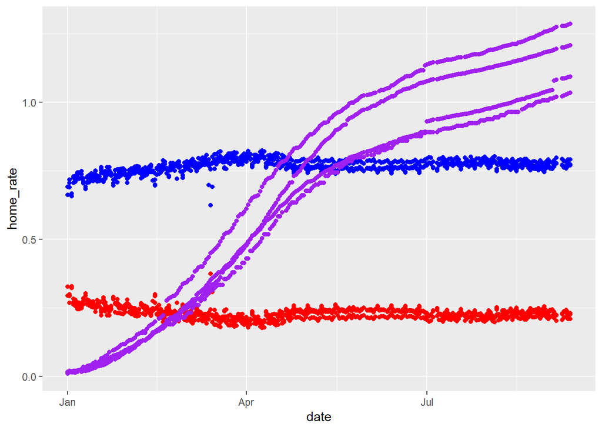

```r
us_regression_data %>% ggplot() + geom_point(aes(x = date, y = home_rate), color = "red")+
  geom_point(aes(x = date, y = not_home_rate), color = "blue")+geom_point(aes(x = date, y = vaccine_rate), color = "purple")
```

## Training Data Creation

```r
set.seed(222)

sample_size = round(nrow(us_regression_data_selected)*.70) # setting what is 70%
index <- sample(seq_len(nrow(us_regression_data_selected)), size = sample_size)

train <- us_regression_data_selected[index, ]
test <- us_regression_data_selected[-index, ]
```

## Model Creation

```r
mod <- lm(total_cases ~ vaccine_rate+home_rate+not_home_rate, data = train)

summary(mod)
```

```
##
## Call:
## lm(formula = total_cases ~ vaccine_rate + home_rate + not_home_rate,
##     data = train)
##
## Residuals:
##     Min      1Q  Median      3Q     Max
## -333900 -210199  -62683   74689  511285
##
## Coefficients:
##               Estimate Std. Error t value Pr(>|t|)
## (Intercept)    9217457    2647288   3.482 0.000530 ***
## vaccine_rate    190821      34160   5.586 3.37e-08 ***
## home_rate     -7719167    2753547  -2.803 0.005202 **
## not_home_rate -9241492    2651015  -3.486 0.000522 ***
## ---
## Signif. codes:  0 '***' 0.001 '**' 0.01 '*' 0.05 '.' 0.1 ' ' 1
##
## Residual standard error: 248800 on 676 degrees of freedom
## Multiple R-squared:  0.05183,    Adjusted R-squared:  0.04762
## F-statistic: 12.32 on 3 and 676 DF,  p-value: 7.471e-08
```

```r
mod_num_change_cases <- lm(number_change_cases ~ vaccine_rate+home_rate+not_home_rate, data = train)

summary(mod_num_change_cases)
```

```
##
## Call:
## lm(formula = number_change_cases ~ vaccine_rate + home_rate +
##     not_home_rate, data = train)
##
## Residuals:
##     Min      1Q  Median      3Q     Max
## -2659.1  -643.3  -292.5   317.7 18423.9
##
## Coefficients:
##                Estimate Std. Error t value Pr(>|t|)
## (Intercept)    149163.2    15147.1   9.848   <2e-16 ***
## vaccine_rate      405.8      195.5   2.076   0.0383 *
## home_rate     -137859.0    15755.1  -8.750   <2e-16 ***
## not_home_rate -151950.4    15168.4 -10.018   <2e-16 ***
## ---
## Signif. codes:  0 '***' 0.001 '**' 0.01 '*' 0.05 '.' 0.1 ' ' 1
##
## Residual standard error: 1424 on 676 degrees of freedom
## Multiple R-squared:  0.2382, Adjusted R-squared:  0.2349
## F-statistic: 70.47 on 3 and 676 DF,  p-value: < 2.2e-16
```

```r
mod_death <- lm(total_deaths ~ vaccine_rate+home_rate+not_home_rate, data = train)

summary(mod_death)
```

```
##
## Call:
## lm(formula = total_deaths ~ vaccine_rate + home_rate + not_home_rate,
##     data = train)
##
## Residuals:
##     Min      1Q  Median      3Q     Max
## -6823.1 -3784.1 -2266.5   116.3 11118.1
##
## Coefficients:
##                Estimate Std. Error t value Pr(>|t|)
## (Intercept)    119621.6    60764.4   1.969 0.049406 *
## vaccine_rate     2952.6      784.1   3.766 0.000181 ***
## home_rate     -103296.9    63203.4  -1.634 0.102650
## not_home_rate -118053.7    60849.9  -1.940 0.052786 .
## ---
## Signif. codes:  0 '***' 0.001 '**' 0.01 '*' 0.05 '.' 0.1 ' ' 1
##
## Residual standard error: 5712 on 676 degrees of freedom
## Multiple R-squared:  0.02148,    Adjusted R-squared:  0.01713
## F-statistic: 4.945 on 3 and 676 DF,  p-value: 0.002105
```

```r
mod_num_change_deaths <- lm(number_change_death ~ vaccine_rate+home_rate+not_home_rate, data = train)

summary(mod_num_change_deaths)
```

```
##
## Call:
## lm(formula = number_change_death ~ vaccine_rate + home_rate +
##     not_home_rate, data = train)
##
## Residuals:
##    Min     1Q Median     3Q    Max
## -64.22  -7.57  -3.63   3.33 430.91
##
## Coefficients:
##               Estimate Std. Error t value Pr(>|t|)
## (Intercept)    3350.91     367.37   9.121   <2e-16 ***
## vaccine_rate     -6.42       4.74  -1.354    0.176
## home_rate     -3324.83     382.12  -8.701   <2e-16 ***
## not_home_rate -3341.13     367.89  -9.082   <2e-16 ***
## ---
## Signif. codes:  0 '***' 0.001 '**' 0.01 '*' 0.05 '.' 0.1 ' ' 1
##
## Residual standard error: 34.53 on 676 degrees of freedom
## Multiple R-squared:  0.2196, Adjusted R-squared:  0.2162
## F-statistic: 63.41 on 3 and 676 DF,  p-value: < 2.2e-16
```

```r
mod_pct <- lm(pct_change_cases ~ vaccine_rate+home_rate+not_home_rate, data = train)

summary(mod_pct)
```

```
##
## Call:
## lm(formula = pct_change_cases ~ vaccine_rate + home_rate + not_home_rate,
##     data = train)
##
## Residuals:
##      Min       1Q   Median       3Q      Max
## -0.51668 -0.14428 -0.05075  0.06630  3.10369
##
## Coefficients:
##                Estimate Std. Error t value Pr(>|t|)
## (Intercept)    15.22053    2.98847   5.093 4.57e-07 ***
## vaccine_rate   -0.15113    0.03856  -3.919 9.80e-05 ***
## home_rate     -12.05728    3.10843  -3.879 0.000115 ***
## not_home_rate -15.77382    2.99268  -5.271 1.83e-07 ***
## ---
## Signif. codes:  0 '***' 0.001 '**' 0.01 '*' 0.05 '.' 0.1 ' ' 1
##
## Residual standard error: 0.2809 on 676 degrees of freedom
## Multiple R-squared:  0.2695, Adjusted R-squared:  0.2663
## F-statistic: 83.14 on 3 and 676 DF,  p-value: < 2.2e-16
```

```r
mod_pct_death <- lm(pct_change_death ~ vaccine_rate+home_rate+not_home_rate, data = train)

summary(mod_pct)
```

```
##
## Call:
## lm(formula = pct_change_cases ~ vaccine_rate + home_rate + not_home_rate,
##     data = train)
##
## Residuals:
##      Min       1Q   Median       3Q      Max
## -0.51668 -0.14428 -0.05075  0.06630  3.10369
##
## Coefficients:
##                Estimate Std. Error t value Pr(>|t|)
## (Intercept)    15.22053    2.98847   5.093 4.57e-07 ***
## vaccine_rate   -0.15113    0.03856  -3.919 9.80e-05 ***
## home_rate     -12.05728    3.10843  -3.879 0.000115 ***
## not_home_rate -15.77382    2.99268  -5.271 1.83e-07 ***
## ---
## Signif. codes:  0 '***' 0.001 '**' 0.01 '*' 0.05 '.' 0.1 ' ' 1
##
## Residual standard error: 0.2809 on 676 degrees of freedom
## Multiple R-squared:  0.2695, Adjusted R-squared:  0.2663
## F-statistic: 83.14 on 3 and 676 DF,  p-value: < 2.2e-16
```

## Predictions

```r
pred = predict(mod_pct, test, interval = "prediction")
conf = predict(mod_pct, test, interval = "confidence")
pred <- as.data.frame(pred)
mod_pct_prediction <- data.frame(pred,test)
#multiVariateDatawPred <- multiVariateData %>% rowwise() %>% mutate(predicted = #list(predict(mod, interval = "prediction")))

#multiVariateDatawPred$predicted
```

```r
pred = predict(mod_death, test, interval = "prediction")
conf = predict(mod_death, test, interval = "confidence")
pred <- as.data.frame(pred)
mod_death_prediction <- data.frame(pred,test)
#multiVariateDatawPred <- multiVariateData %>% rowwise() %>% mutate(predicted = #list(predict(mod, interval = "prediction")))

#multiVariateDatawPred$predicted
```

```r
pred = predict(mod_num_change_cases, test, interval = "prediction")
conf = predict(mod_num_change_cases, test, interval = "confidence")
pred <- as.data.frame(pred)
mod_num_cases_pred <- data.frame(pred,test)
#multiVariateDatawPred <- multiVariateData %>% rowwise() %>% mutate(predicted = #list(predict(mod, interval = "prediction")))

#multiVariateDatawPred$predicted
```

```r
pred = predict(mod_num_change_deaths, test, interval = "prediction")
conf = predict(mod_death, test, interval = "confidence")
pred <- as.data.frame(pred)
mod_num_death_pred <- data.frame(pred,test)
#multiVariateDatawPred <- multiVariateData %>% rowwise() %>% mutate(predicted = #list(predict(mod, interval = "prediction")))

#multiVariateDatawPred$predicted
```

```r
pred = predict(mod_pct_death, test, interval = "prediction")
conf = predict(mod_pct_death, test, interval = "confidence")
pred <- as.data.frame(pred)
mod_pct_death_prediction <- data.frame(pred,test)
#multiVariateDatawPred <- multiVariateData %>% rowwise() %>% mutate(predicted = #list(predict(mod, interval = "prediction")))

#multiVariateDatawPred$predicted
```

```r
pred = predict(mod, test, interval = "prediction")
conf = predict(mod, test, interval = "confidence")
pred <- as.data.frame(pred)
total_cases_prediction <- data.frame(pred,test)
#multiVariateDatawPred <- multiVariateData %>% rowwise() %>% mutate(predicted = #list(predict(mod, interval = "prediction")))

#multiVariateDatawPred$predicted
```

## Plot of Predictions vs features

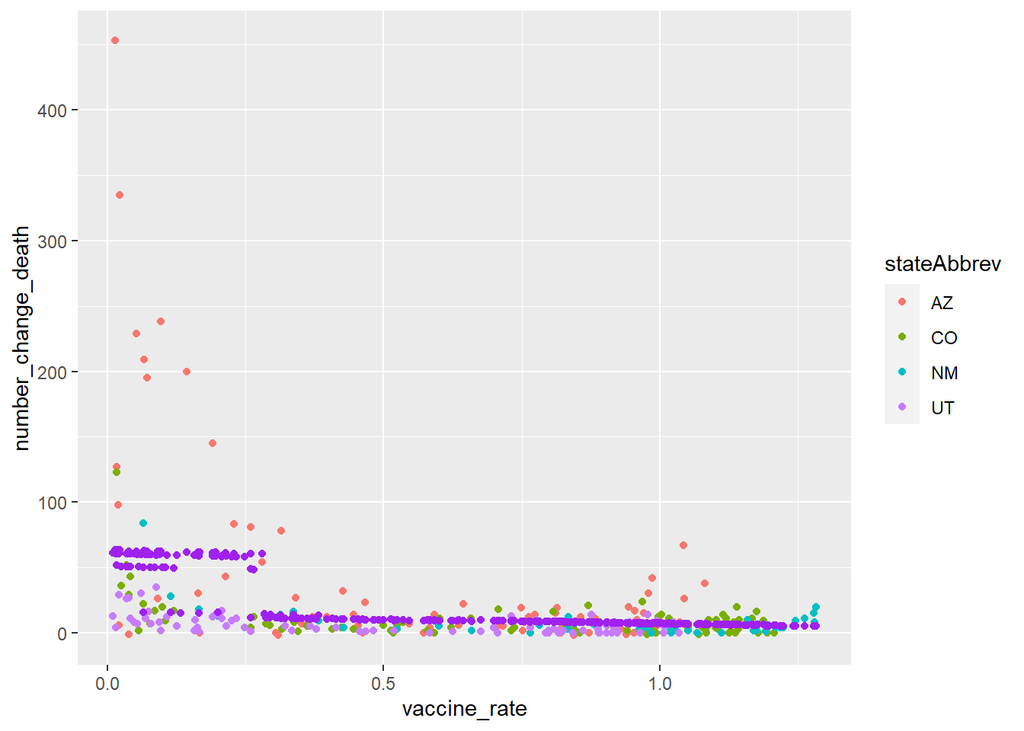

```r
mod_num_death_pred %>% ggplot() + geom_point(aes(x = vaccine_rate, y = number_change_death, color = stateAbbrev))+
  geom_point(aes(x = vaccine_rate, y = fit), color ="purple")
```

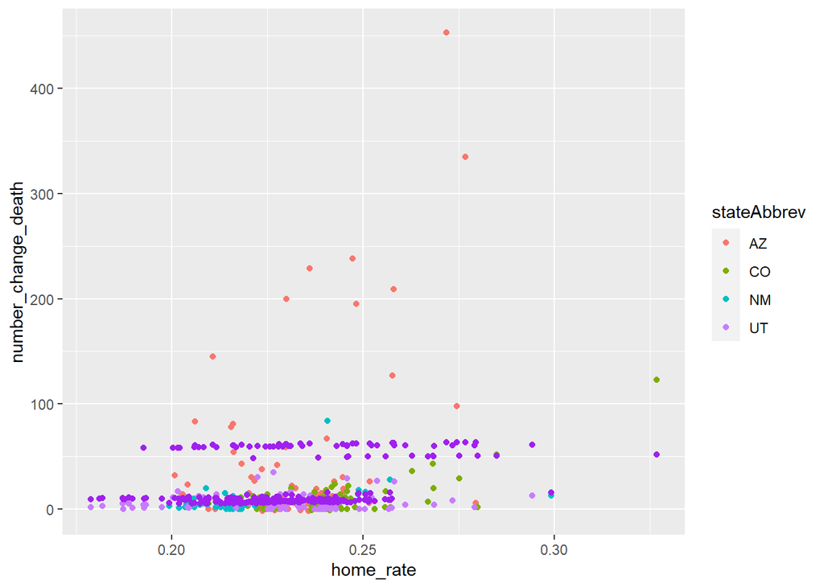

```r
mod_num_death_pred %>% ggplot() + geom_point(aes(x = home_rate, y = number_change_death, color = stateAbbrev))+
  geom_point(aes(x = home_rate, y = fit), color ="purple")
```

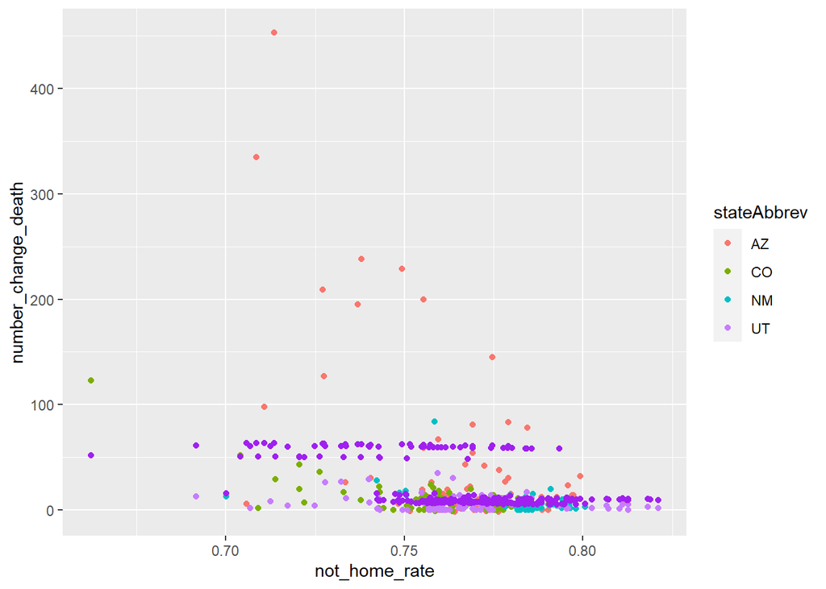

```r
mod_num_death_pred %>% ggplot() + geom_point(aes(x = not_home_rate, y = number_change_death, color = stateAbbrev))+
  geom_point(aes(x = not_home_rate, y = fit), color ="purple")
```

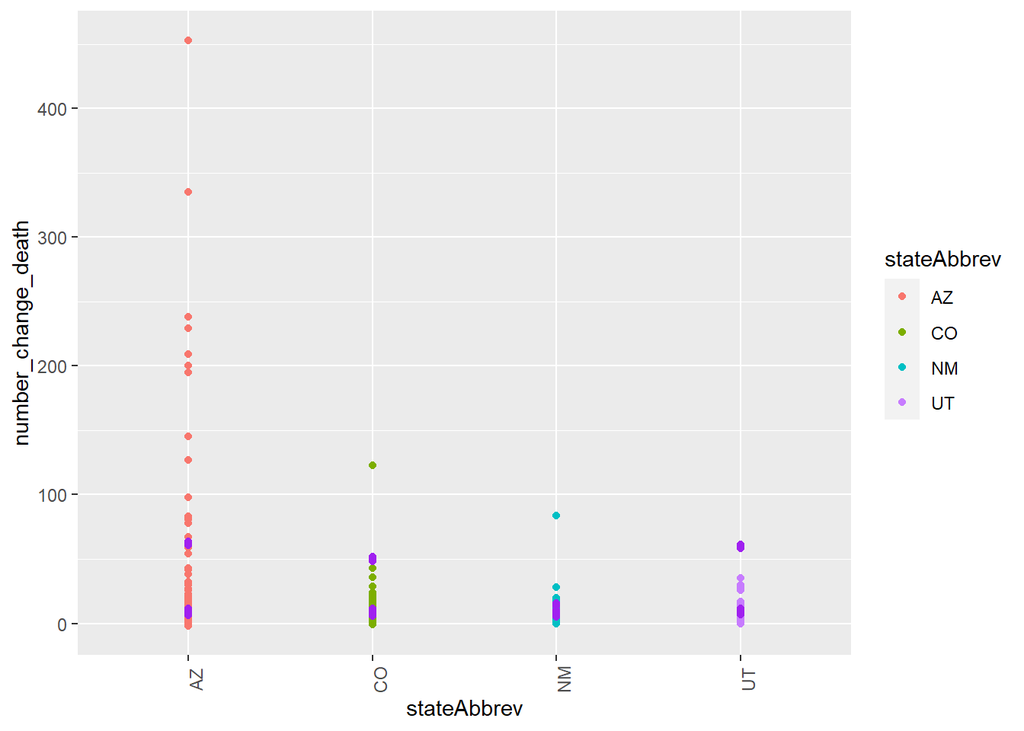

```r
mod_num_death_pred %>% ggplot() + geom_point(aes(x = stateAbbrev, y = number_change_death, color = stateAbbrev))+
  geom_point(aes(x = stateAbbrev, y = fit), color ="purple")+theme(axis.text.x = element_text(angle = 90))
```

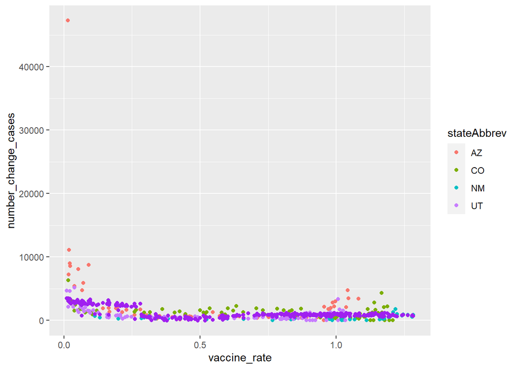

```r
mod_num_cases_pred %>% ggplot() + geom_point(aes(x = vaccine_rate, y = number_change_cases, color = stateAbbrev))+
  geom_point(aes(x = vaccine_rate, y = fit), color ="purple")
```

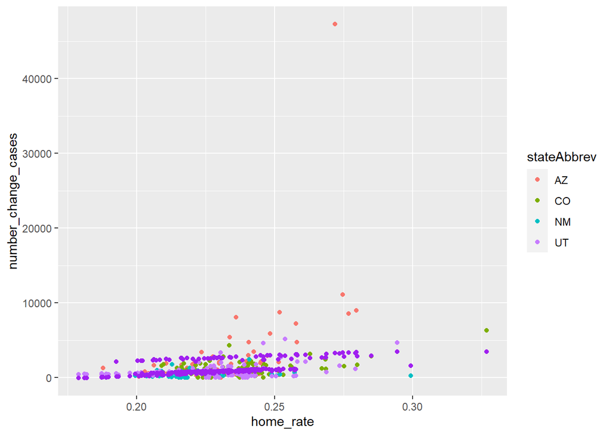

```r
mod_num_cases_pred %>% ggplot() + geom_point(aes(x = home_rate, y = number_change_cases, color = stateAbbrev))+
  geom_point(aes(x = home_rate, y = fit), color ="purple")
```

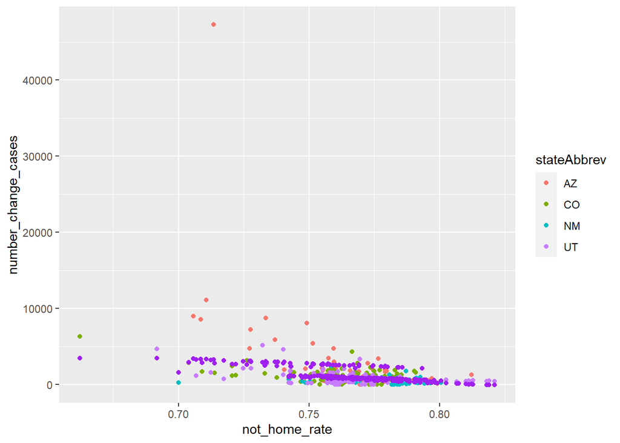

```r
mod_num_cases_pred %>% ggplot() + geom_point(aes(x = not_home_rate, y = number_change_cases, color = stateAbbrev))+
  geom_point(aes(x = not_home_rate, y = fit), color ="purple")
```

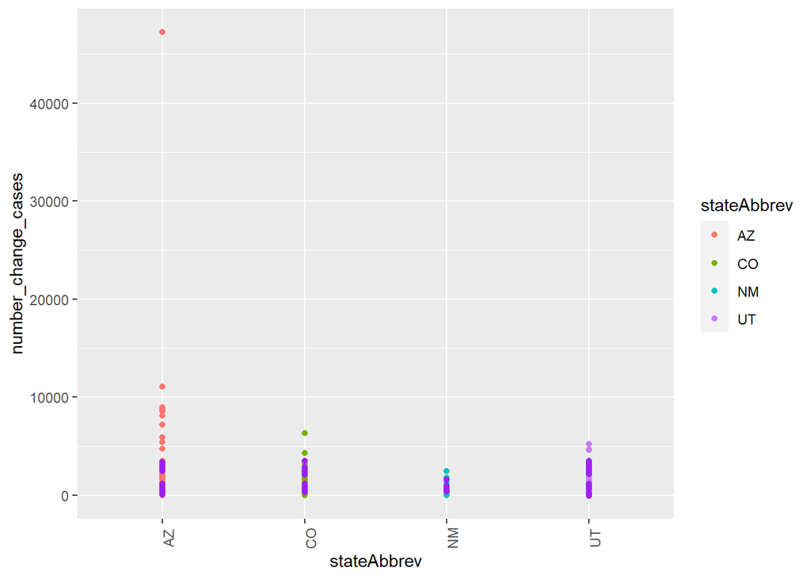

```r
mod_num_cases_pred %>% ggplot() + geom_point(aes(x = stateAbbrev, y = number_change_cases, color = stateAbbrev))+
  geom_point(aes(x = stateAbbrev, y = fit), color ="purple")+theme(axis.text.x = element_text(angle = 90))
```

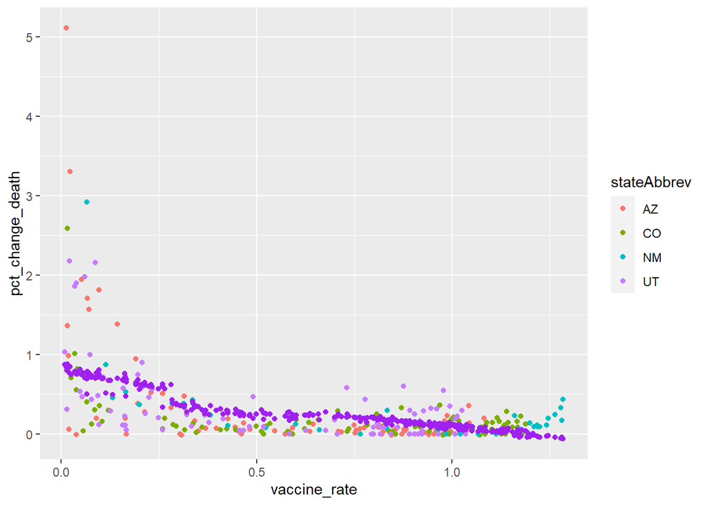

```r
mod_pct_death_prediction %>% ggplot() + geom_point(aes(x = vaccine_rate, y = pct_change_death, color = stateAbbrev))+
  geom_point(aes(x = vaccine_rate, y = fit), color ="purple")
```

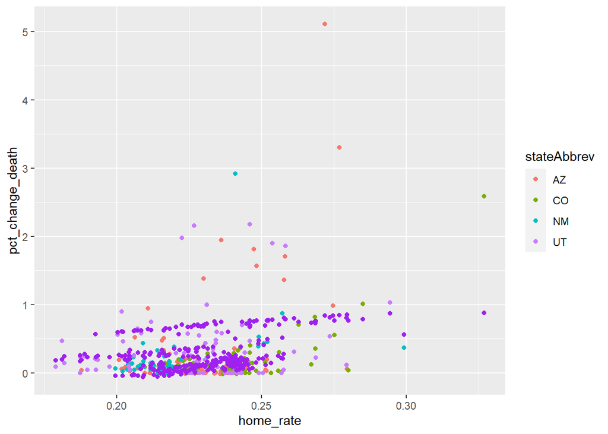

```r
mod_pct_death_prediction %>% ggplot() + geom_point(aes(x = home_rate, y = pct_change_death, color = stateAbbrev))+
  geom_point(aes(x = home_rate, y = fit), color ="purple")
```

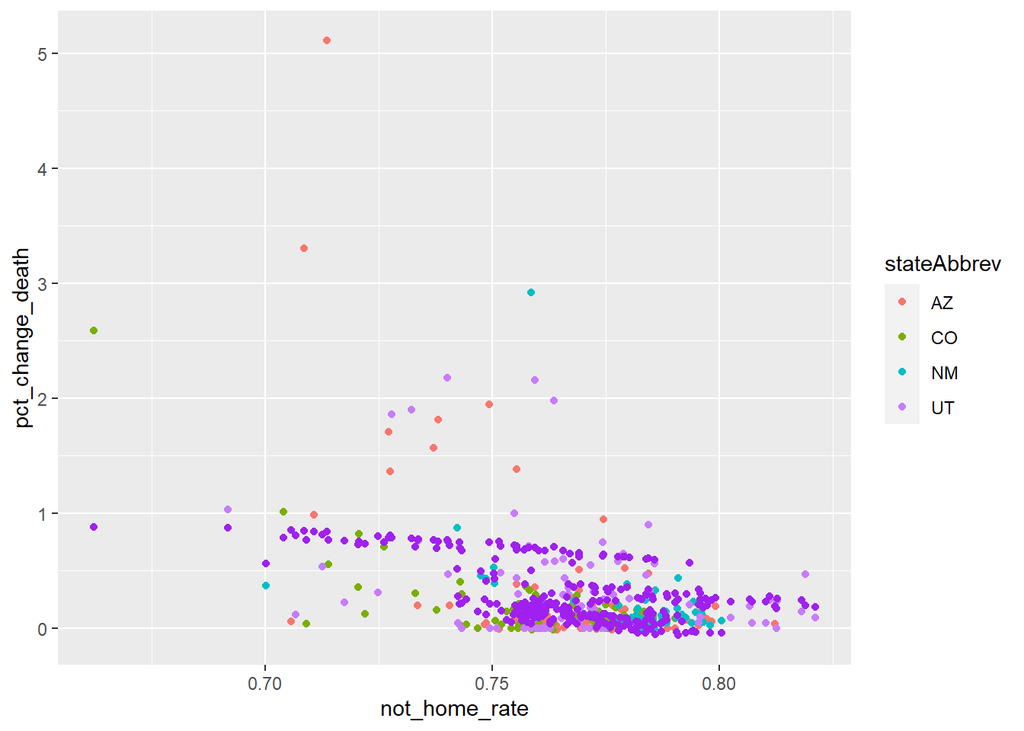

```r
mod_pct_death_prediction %>% ggplot() + geom_point(aes(x = not_home_rate, y = pct_change_death, color = stateAbbrev))+
  geom_point(aes(x = not_home_rate, y = fit), color ="purple")
```

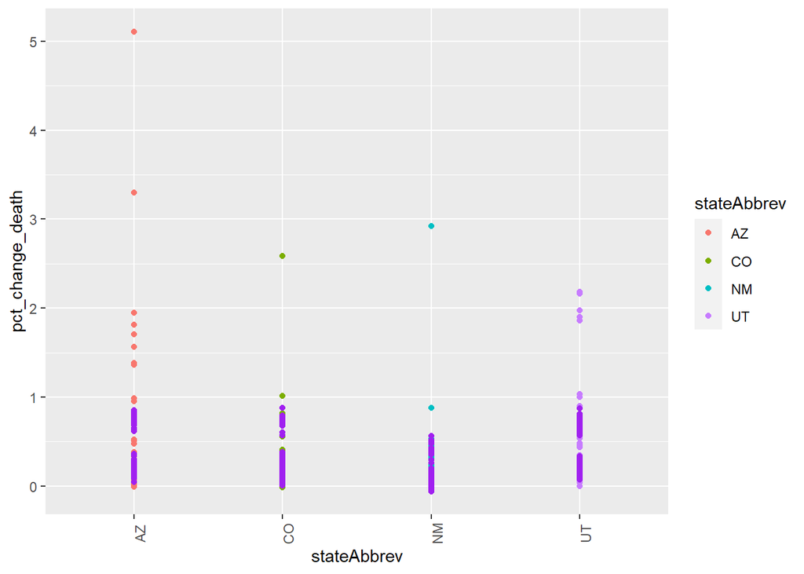

```r
mod_pct_death_prediction %>% ggplot() + geom_point(aes(x = stateAbbrev, y = pct_change_death, color = stateAbbrev))+
  geom_point(aes(x = stateAbbrev, y = fit), color ="purple")+theme(axis.text.x = element_text(angle = 90))
```

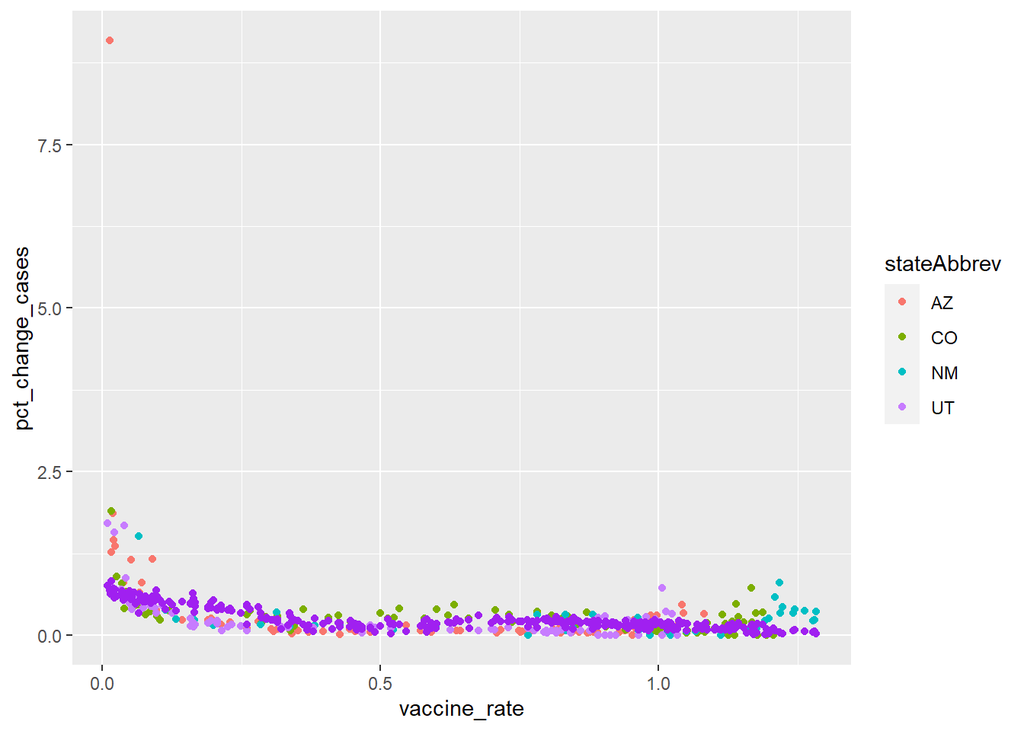

```r
mod_pct_prediction %>% ggplot() + geom_point(aes(x = vaccine_rate, y = pct_change_cases, color = stateAbbrev))+
  geom_point(aes(x = vaccine_rate, y = fit), color ="purple")
```

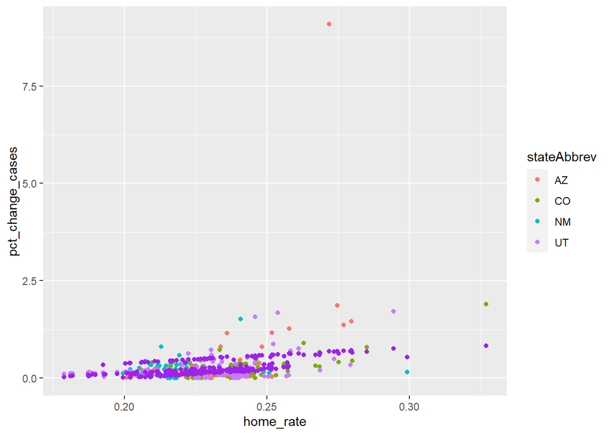

```r
mod_pct_prediction %>% ggplot() + geom_point(aes(x = home_rate, y = pct_change_cases, color = stateAbbrev))+
  geom_point(aes(x = home_rate, y = fit), color ="purple")
```

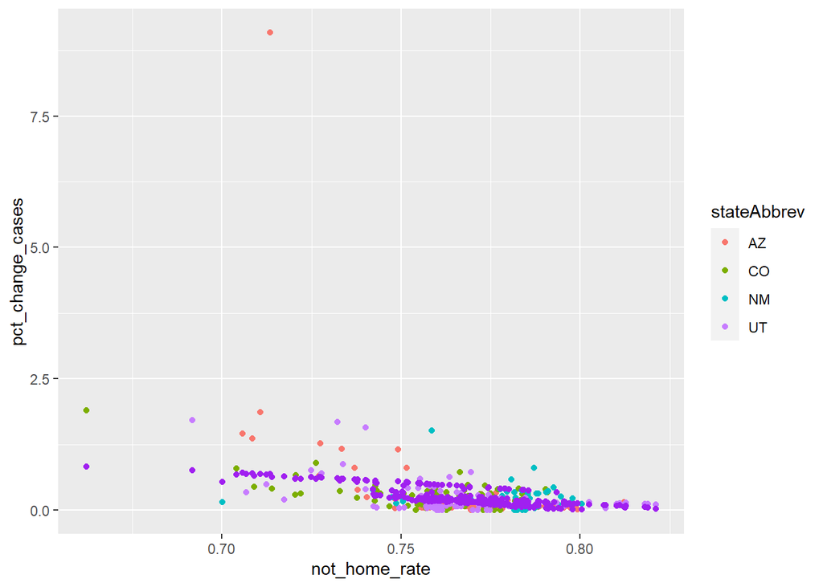

```r
mod_pct_prediction %>% ggplot() + geom_point(aes(x = not_home_rate, y = pct_change_cases, color = stateAbbrev))+
  geom_point(aes(x = not_home_rate, y = fit), color ="purple")
```

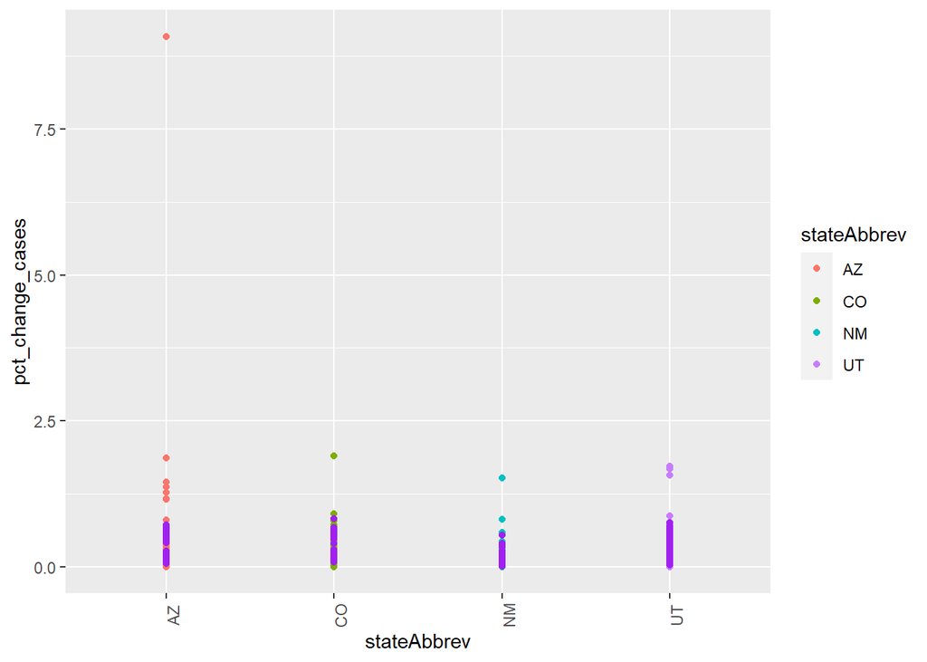

```r
mod_pct_prediction %>% ggplot() + geom_point(aes(x = stateAbbrev, y = pct_change_cases, color = stateAbbrev))+
  geom_point(aes(x = stateAbbrev, y = fit), color ="purple")+theme(axis.text.x = element_text(angle = 90))
```

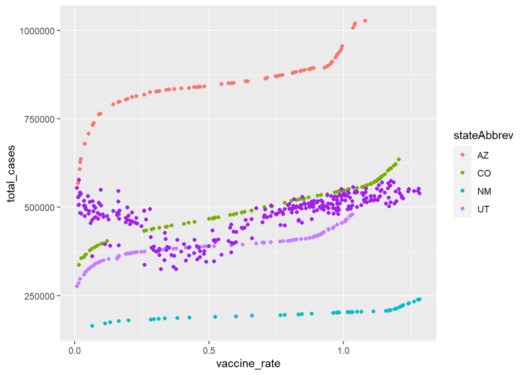

```r
total_cases_prediction %>% ggplot() + geom_point(aes(x = vaccine_rate, y = total_cases, color = stateAbbrev))+
  geom_point(aes(x = vaccine_rate, y = fit), color ="purple")
```

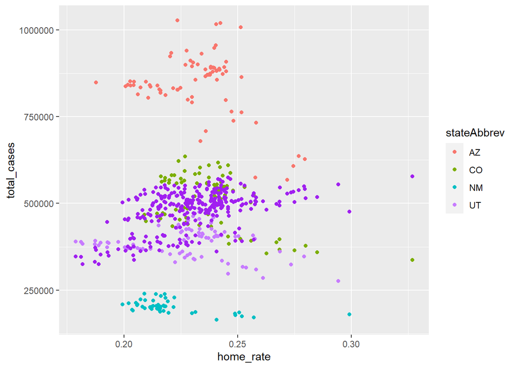

```r
total_cases_prediction %>% ggplot() + geom_point(aes(x = home_rate, y = total_cases, color = stateAbbrev))+
  geom_point(aes(x = home_rate, y = fit), color ="purple")
```

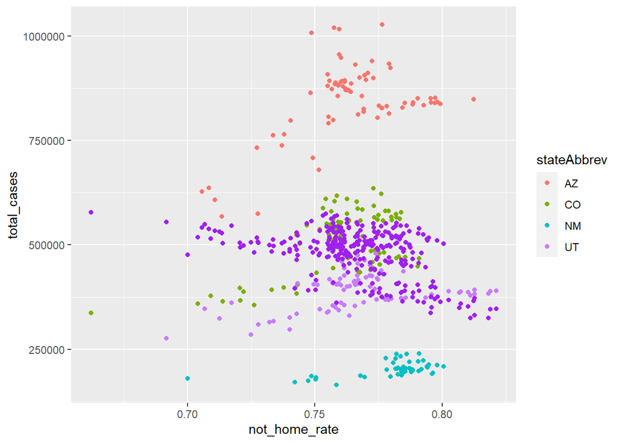

```r
total_cases_prediction %>% ggplot() + geom_point(aes(x = not_home_rate, y = total_cases, color = stateAbbrev))+
  geom_point(aes(x = not_home_rate, y = fit), color ="purple")
```

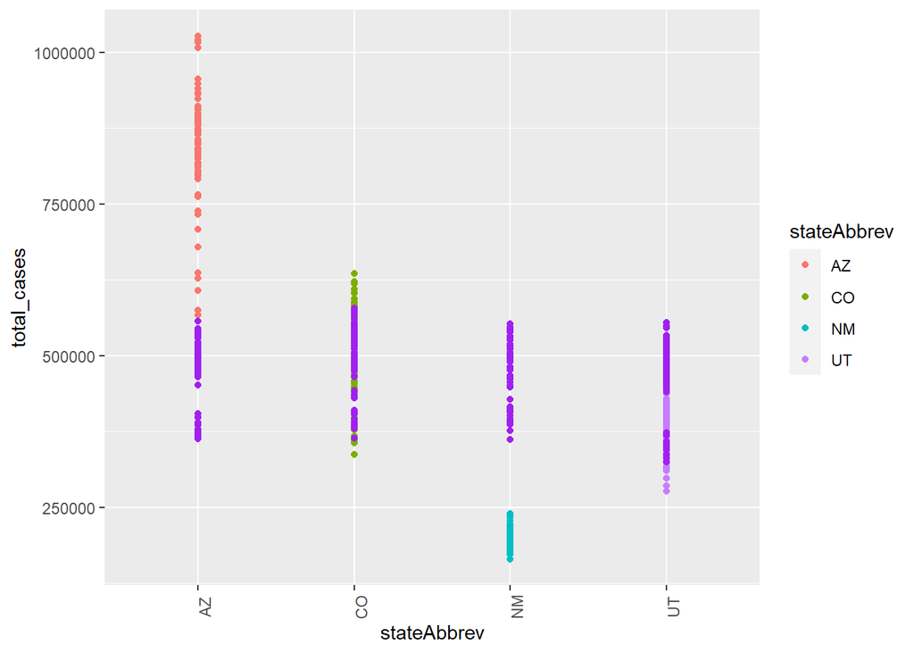

```r
total_cases_prediction %>% ggplot() + geom_point(aes(x = stateAbbrev, y = total_cases, color = stateAbbrev))+
  geom_point(aes(x = stateAbbrev, y = fit), color ="purple")+theme(axis.text.x = element_text(angle = 90))
```

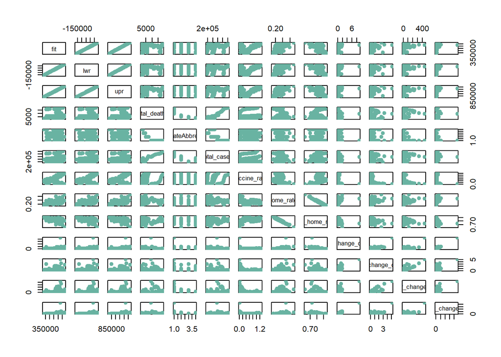

```r
plot(total_cases_prediction , pch=20 , cex=1.5 , col="#69b3a2")
```

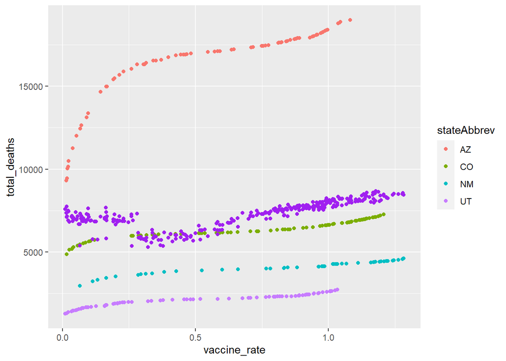

```r
mod_death_prediction %>% ggplot() + geom_point(aes(x = vaccine_rate, y = total_deaths, color = stateAbbrev))+
  geom_point(aes(x = vaccine_rate, y = fit), color ="purple")
```

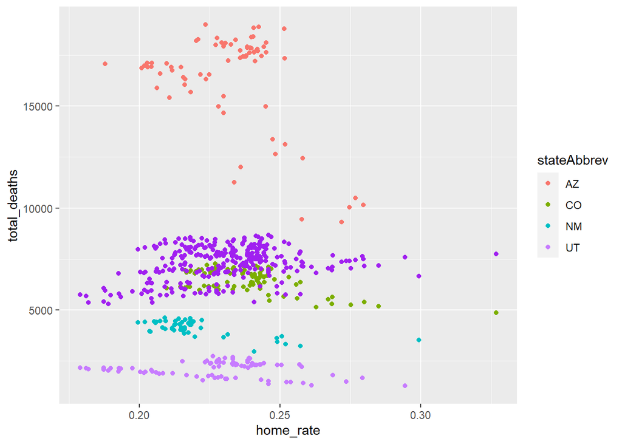

```r
mod_death_prediction %>% ggplot() + geom_point(aes(x = home_rate, y = total_deaths, color = stateAbbrev))+
  geom_point(aes(x = home_rate, y = fit), color ="purple")
```

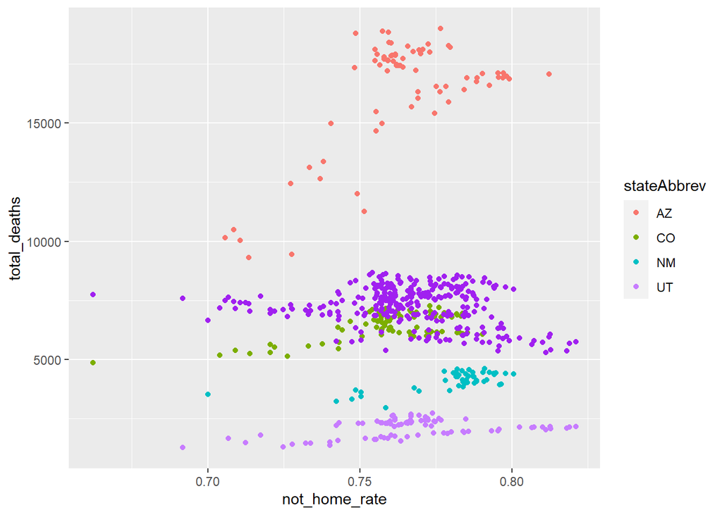

```r
mod_death_prediction %>% ggplot() + geom_point(aes(x = not_home_rate, y = total_deaths, color = stateAbbrev))+
  geom_point(aes(x = not_home_rate, y = fit), color ="purple")
```

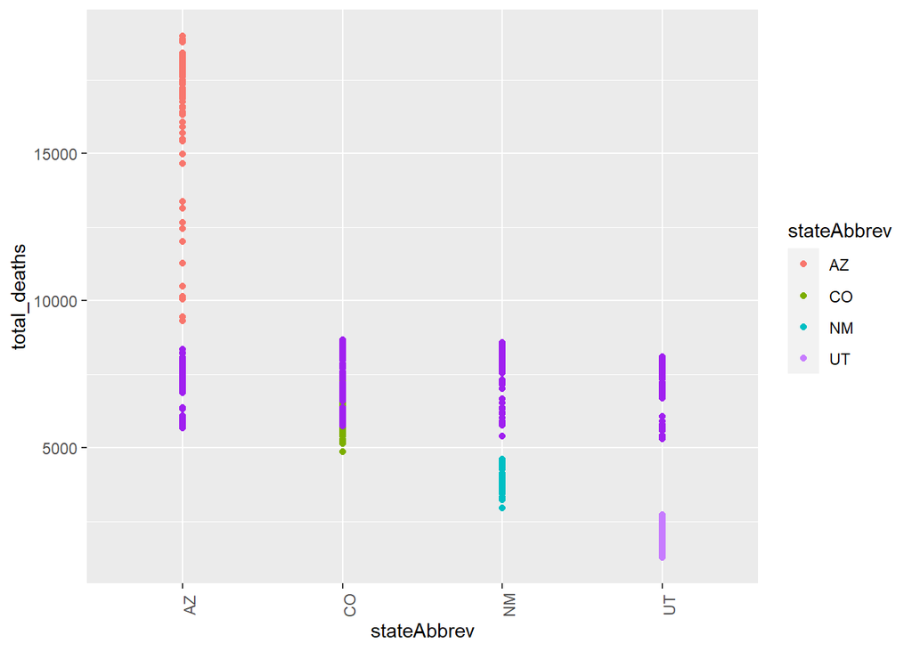

```r
mod_death_prediction %>% ggplot() + geom_point(aes(x = stateAbbrev, y = total_deaths, color = stateAbbrev))+
  geom_point(aes(x = stateAbbrev, y = fit), color ="purple")+theme(axis.text.x = element_text(angle = 90))
```

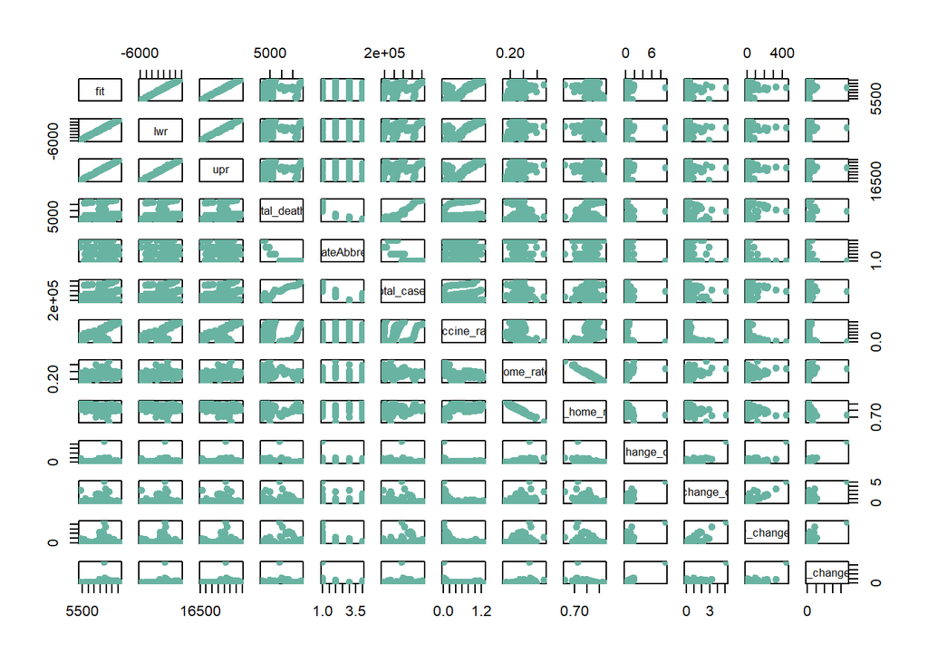

```r
plot(mod_death_prediction , pch=20 , cex=1.5 , col="#69b3a2")
```